# Lab 5

October 31 2017

## Monte Carlo simulations

## Calculating evidence

\(P(\theta | \mathcal{D}) = \frac{P(\mathcal{D} | \theta) \times P(\theta)}{P(\mathcal{D})}\)

posterior = likelihood \(\times\) prior / evidence

How to calculate evidence?

## Calculating evidence

With only 2 or 3 values of \(\theta\) it is fairly simple (recall HW 1):

\(P(\mathcal{D}) = [P(\mathcal{D} | \theta = 1) \times P(\theta = 1)] + [P(\mathcal{D} | \theta = 2) \times P(\theta = 2)]\)

In general we could write:

\(P(\mathcal{D}) = \sum_{\theta} P(\mathcal{D} | \theta) \times P(\theta)\)

## Calculating evidence

Though, usually we will use \(\theta\) with continuous scale (i.e. infinite number of values).

In math we denote summing across values of continuous scale as **integrating**:

\(P(\mathcal{D}) = \int_{\theta} P(\mathcal{D} | \theta) \times P(\theta) \mathrm{d\theta}\)

## Calculating integrals - analytical app.

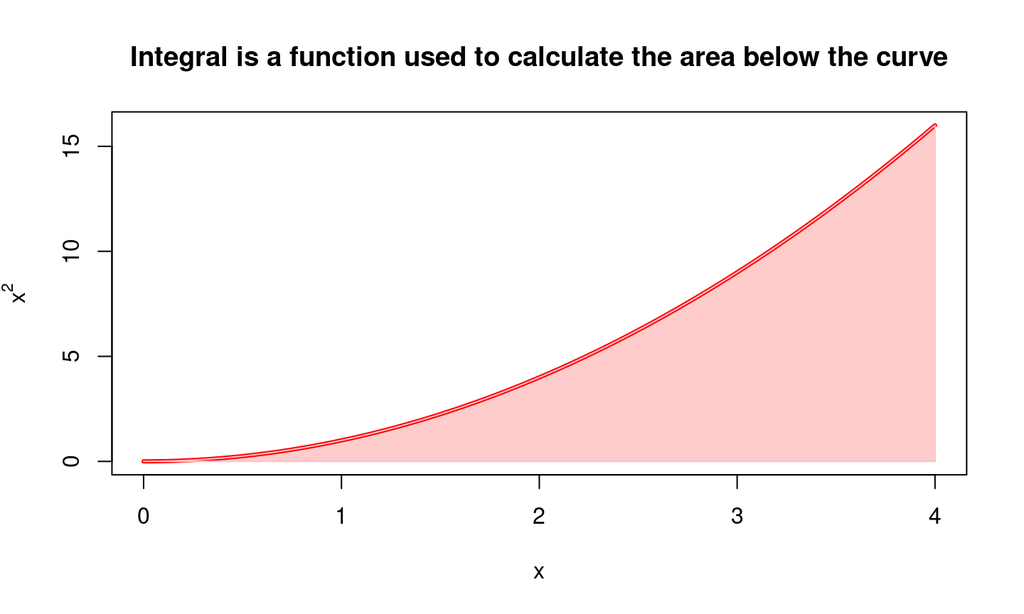

We know from analytical solution: \(\int x^2 \mathrm{dx} = \frac{x^3}{3} + const\)

## Calculating integrals - numerical app.

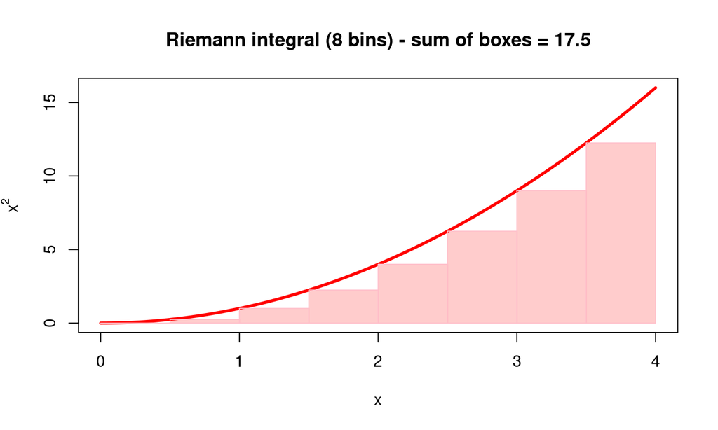

## Calculating integrals - numerical app.

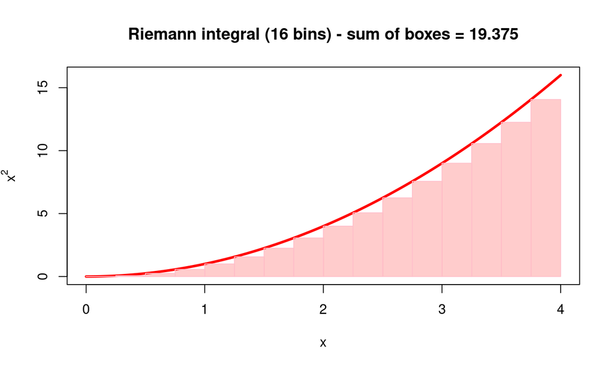

## Calculating integrals - numerical app.

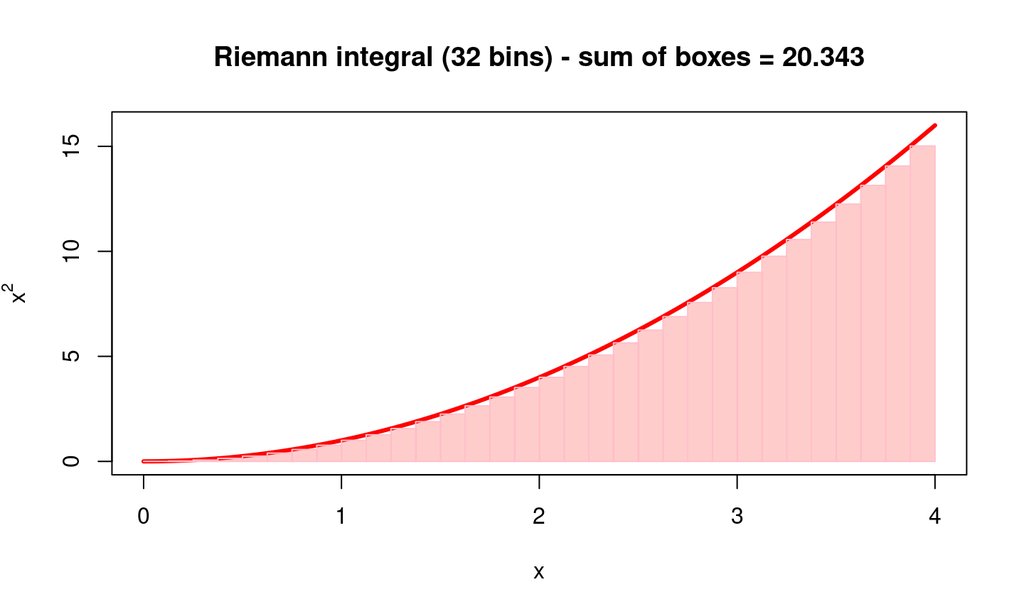

## Calculating integrals - numerical app.

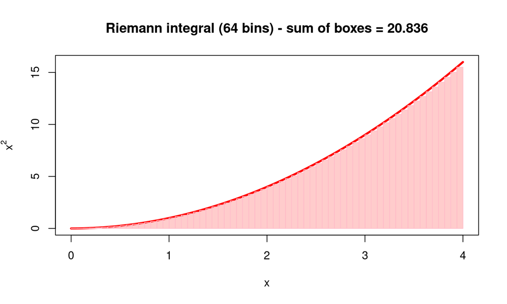

## Computing integrals - numerical app.

- With 1 parameter/dimension CPU has to perform \(100\) operations
- With 2 parameters/dimensions CPU has to perform \(100^2 = 10000\) operations
- With 3 parameters/dimensions CPU has to perform \(100^3 = 1000000\) operations
- With 10 parameters/dimensions CPU has to perform \(100^{10} = 100000000000000000000\) operations
- Numerical approach quickly becomes too hard even for fast computers

## Sampling

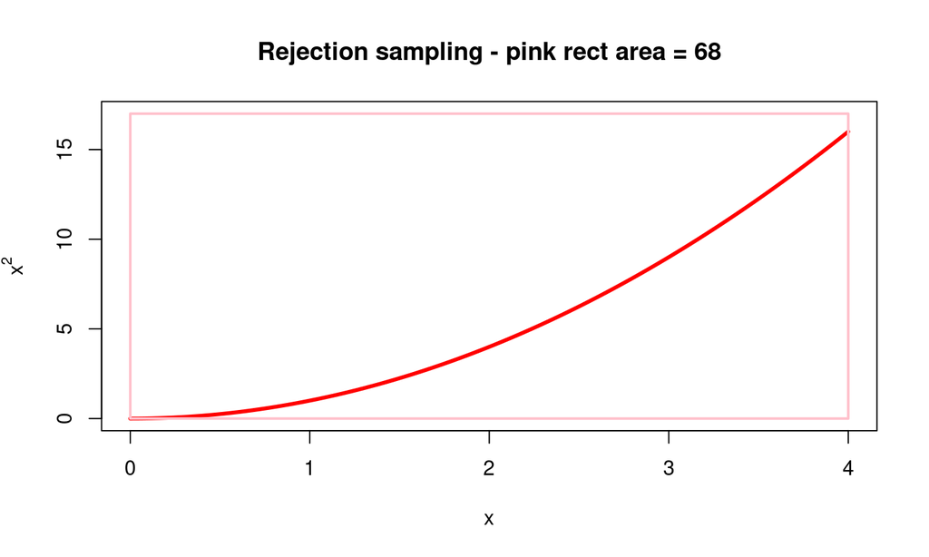

## Sampling

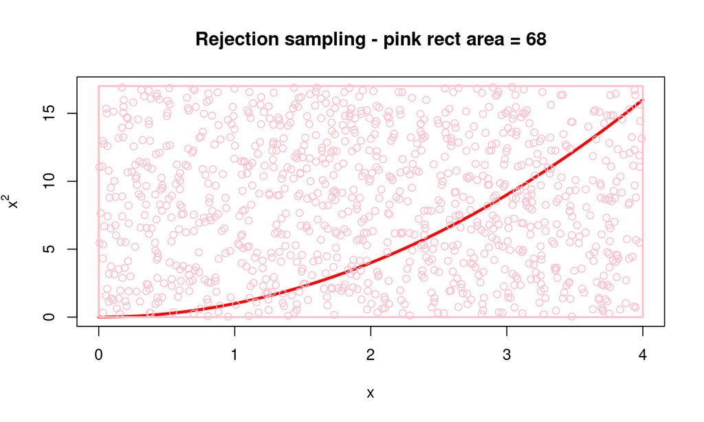

## Sampling

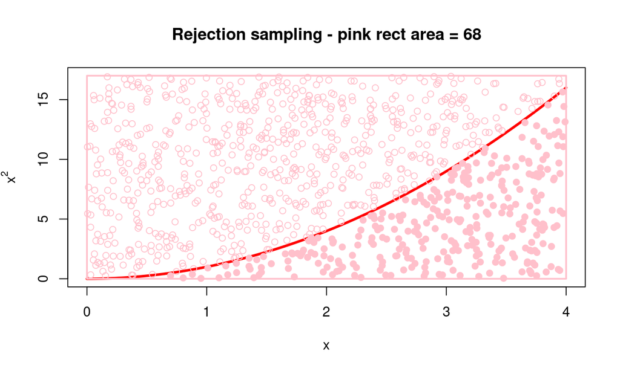

E.g. 318 of 1000 sampled points are below the curve - 0.318. \(68 \times 0.318 = 21.624\)